# 경제자료분석과 예측 - #08 동적회귀모형

2025년 2학기

## 동적 회귀모형 소개 (Dynamic Regression Models)

## 1. 배경

앞 선 두 장의 시계열 모형은 시계열의 **과거 관측값만** 사용하지만,휴일, 경쟁사 활동, 법률 변화, 거시경제 상황 등 **외부 요인**도 변동성 설명 및 예측 향상에 중요한 역할을 할 수 있다.

반면 회귀모형은 다양한 예측변수를 포함할 수 있으나 ARIMA가 제공하는 **시계열 동학(time series dynamics)**을 반영하지 못한다.

이 장에서는 **ARIMA 모형을 확장하여 외부 정보(예측변수)를 포함하는 방법**을 다룬다.

## 2. 회귀모형 복습

회귀모형은 다음과 같다.

\[ y_t = \beta_0 + \beta_1 x_{1,t} + \cdots + \beta_k x_{k,t} + \varepsilon_t \]

- \(y_t\): 종속변수
- \(x_{1,t}, \dots, x_{k,t}\): 예측변수
- \(\varepsilon_t\): 백색잡음(white noise) 오차

잔차의 자기상관 여부는 **Ljung–Box test** 등으로 확인한다.

## 3. 회귀모형의 오차에 자기상관 허용

이 장에서는 회귀모형의 오차가 **자기상관을 가질 수 있도록** 설정한다.

이를 위해 오차항 표기를 \(\varepsilon_t \rightarrow \eta_t\)로 변경한다.

오차항 \(\eta_t\)는 **ARIMA 모형**을 따른다고 가정한다.

예: \(\eta_t \sim \text{ARIMA}(1,1,1)\)

\[ y_t = \beta_0 + \beta_1 x_{1,t} + \cdots + \beta_k x_{k,t} + \eta_t \]

\[ (1 - \phi_1 B)(1 - B)\eta_t = (1 + \theta_1 B)\varepsilon_t \]

여기서 \(\varepsilon_t\)는 백색잡음이다.

## 4. 오차항의 구성

모형에는 **두 종류의 오차항**이 존재한다.

1. **회귀모형 오차:** \(\eta_t\)
2. **ARIMA 오차:** \(\varepsilon_t\)

단, 백색잡음으로 가정하는 것은 **ARIMA 오차 \(\varepsilon_t\)**뿐이다.

### 요약

- 단순 회귀모형 + ARIMA 오차 구조 → 더 강력한 예측 가능
- 외생변수 포함 + 시계열 동학 반영
- 동적회귀모형의 핵심 개념을 구성하는 출발점

## 회귀 + ARIMA 오차: 추정의 핵심 원리

## 1. 왜 \(\varepsilon_t\)의 제곱합을 최소화해야 하는가?

회귀식의 오차항을 ARIMA 구조로 모델링할 경우, 모수추정은 **\(\varepsilon_t\)(ARIMA 오차)의 제곱합 최소화**를 기준으로 이루어진다.

만약 오차의 자기상관을 무시하고 **\(\eta_t\)(단순 회귀잔차)**의 제곱합을 최소화하면 다음 문제가 발생한다.

## 1. 왜 \(\varepsilon_t\)의 제곱합을 최소화해야 하는가?

### 발생하는 문제들

1. **계수 추정값 \(\hat{\beta}_t\)가 최적이 아님**
   - 자기상관을 무시하여 정보 손실 발생
2. **t-검정 등 통계검정이 잘못됨**
3. **AICc 기반 모형비교가 무의미**
4. **p-값이 실제보다 작게 평가됨 → 가짜 회귀(spurious regression)**
   - 중요하지 않은 변수가 중요한 것처럼 보임

### 대안

- \(\varepsilon_t\) 최소화가 정답
- 또는 **최대우도추정(MLE)**을 사용해도 유사한 결과를 얻음

## 2. 정상성 요구사항

ARMA 오차를 포함한 회귀모형 추정 시에는 다음이 **반드시 정상성**이어야 한다.

- 종속변수 \(y_t\)
- 모든 예측변수 \(x_{1,t}, \dots, x_{k,t}\)

### 정상성이 필요하지 않은 예외

- **공적분(cointegration)**이 존재하는 경우
- 비정상 변수들이 특정 선형결합을 이루어 정상성을 가지면  
  → 계수는 **일관적 추정량(consistenct)**

## 3. 비정상 변수 → 차분 필요

비정상 변수가 존재하면 **차분(differencing) 수행**  
관계식의 형태를 유지하기 위해 보통 **모든 변수 전체를 차분**

### 용어 구분

- **모델 in levels:** 원자료를 그대로 사용
- **모델 in differences:** 차분된 자료를 사용

## 4. ARIMA 오차모형의 동등한 표현

모든 변수가 정상적이면, 오차항에 대해 **ARMA 과정만** 고려하면 됨.

ARIMA(1,1,1) 오차를 가진 회귀모형을 차분하면:

### 차분된 형태

\[ y'_t = \beta_1 x'_{1,t} + \cdots + \beta_k x'_{k,t} + \eta'_t \]

오차 구조: \[ (1 - \phi_1 B)\eta'_t = (1 + \theta_1 B)\varepsilon_t \]

여기서  
- \(y'_t = y_t - y_{t-1}\)  
- \(x'_{i,t} = x_{i,t} - x_{i,t-1}\)  
- \(\eta'_t = \eta_t - \eta_{t-1}\)

## 4. ARIMA 오차모형의 동등한 표현

### 핵심 결론

> **회귀모형 + ARIMA 오차 = 차분된 회귀모형 + ARMA 오차**

### 요약

- 오차의 자기상관을 고려하지 않으면 추정, 검정, 모형비교 모두 왜곡
- 정상성은 필수, 공적분은 예외
- ARIMA 오차모형은 차분모형과 해석적으로 동등

## ARIMA 오차를 이용한 회귀분석 feat. fable

## 1. ARIMA()의 기본 동작

- formula에 외생변수(x)를 포함하면  
  → **ARIMA 오차를 가진 회귀모형**을 적합
- `pdq(p,d,q)`는 **오차항의 ARIMA 차수 지정**

### 차분(differencing)을 지정하면?

→ 회귀식의 **모든 변수에 차분을 동일하게 적용**

## 2. 예시

```r
ARIMA(y ~ x + pdq(1,1,0))
```

```
## <ARIMA model definition>
```

다음 명령은 다음의 차분모형을 적합한다.

\[ y'_t = \beta_1 x'_t + \eta'_t \]

오차항은 AR(1) 구조를 갖는다.

\[ \eta'_t = \phi_1 \eta'_{t-1} + \varepsilon_t \]

## 2. 동등한 수준(Level) 모형

위 모형은 다음 수준모형과 동등하다.

\[ y_t = \beta_0 + \beta_1 x_t + \eta_t \]

- \(\eta_t\): **ARIMA(1,1,0)** 오차
- 차분(differencing) 때문에 **상수항 \(\beta_0\) 사라짐**

### 차분된 모형에 상수를 포함하려면?

model formula에 `+ 1` 추가

## 3. 자동 ARIMA 오차 선택 기능

`pdq()`를 지정하지 않으면 **오차항 ARIMA 자동 선택**

### 절차

1. OLS 회귀식 추정
2. 잔차에 **KPSS test** 적용 → 정상성 판단
3. 비정상적이면 **모든 변수 차분**
4. 차분된 데이터로 **최대우도추정(MLE)** 재적합
5. 결과는 **원래(level) 변수 기준**으로 출력됨

## 4. AICc 기반 예측변수 선택

- 최종 모형의 **AICc 계산**
- 고려할 predictor subset 전체에 대해 절차 반복
- **AICc 최소 모델** 선택

## 예제: 미국 소비(Consumption)와 소득(Income)의 변화율 관계

## 1. 데이터 개요

- 기간: 1970 ~ 2019 Q2
- 변수:
  - 개인 소비지출(percentage change)
  - 개인 가처분소득(percentage change)

### 분석 목표

소득 변화가 소비 변화에 미치는 **즉각적 평균 효과** 추정

> 현실적으로 소득 변화 → 소비 변화까지 시차가 있지만 본 예제에서는 단순화를 위해 무시함.

## 1. 데이터 개요

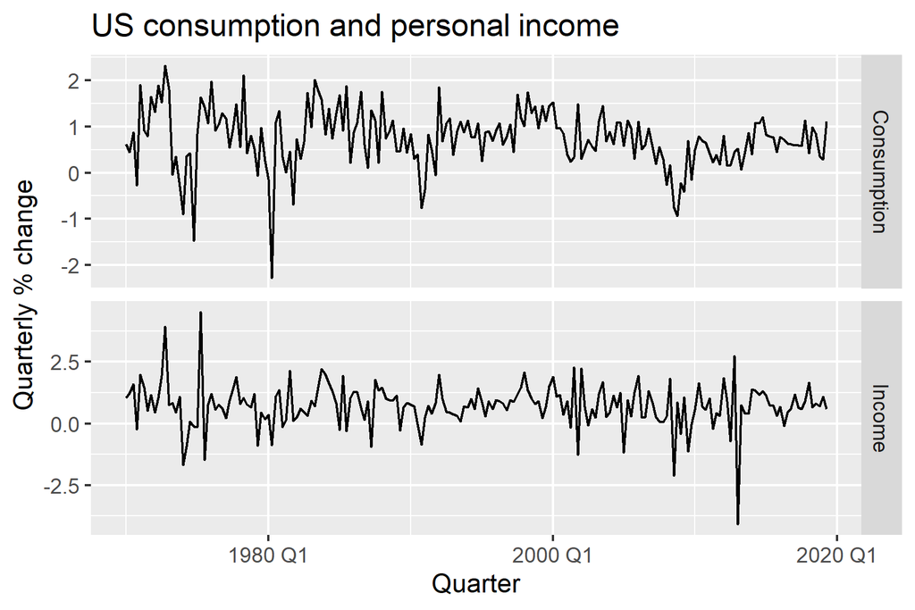

## 2. 정상성 확인

- 변수들이 **변화율**이므로 이미 **정상성** 가정 충족
- → 차분( 불필요

```r
fit <- us_change |>
  model(ARIMA(Consumption ~ Income))
report(fit)
```

```
## Series: Consumption
## Model: LM w/ ARIMA(1,0,2) errors
##
## Coefficients:
##          ar1      ma1     ma2  Income  intercept
##       0.7070  -0.6172  0.2066  0.1976     0.5949
## s.e.  0.1068   0.1218  0.0741  0.0462     0.0850
##
## sigma^2 estimated as 0.3113:  log likelihood=-163.04
## AIC=338.07   AICc=338.51   BIC=357.8
```

## 3. 적합된 회귀 + ARIMA 오차모형

### (1) 회귀식

\[ y_t = 0.595 + 0.198 x_t + \eta_t \]

### (2) 오차항의 ARIMA 구조

\[ \eta_t = 0.707\eta_{t-1} + \varepsilon_t - 0.617\varepsilon_{t-1} + 0.207\varepsilon_{t-2} \]

### (3) innovation residuals

\[ \varepsilon_t \sim NID(0,\ 0.311) \]

## 4. 잔차 복원

`residuals()` 함수로 다음 두 가지 잔차를 복원할 수 있다.

- \(\eta_t\): 회귀오차
- \(\varepsilon_t\): ARIMA innovation residuals

### 주의

> **백색잡음(white noise)에 가까워야 하는 오차는** **innovation residuals (\(\varepsilon_t\))** 이다.

## 4. 잔차 복원

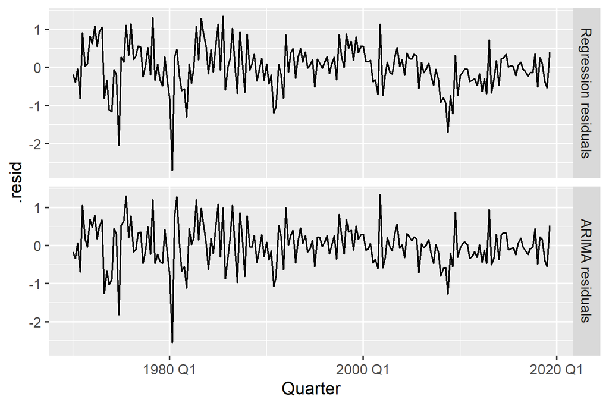

## 4. 잔차 복원

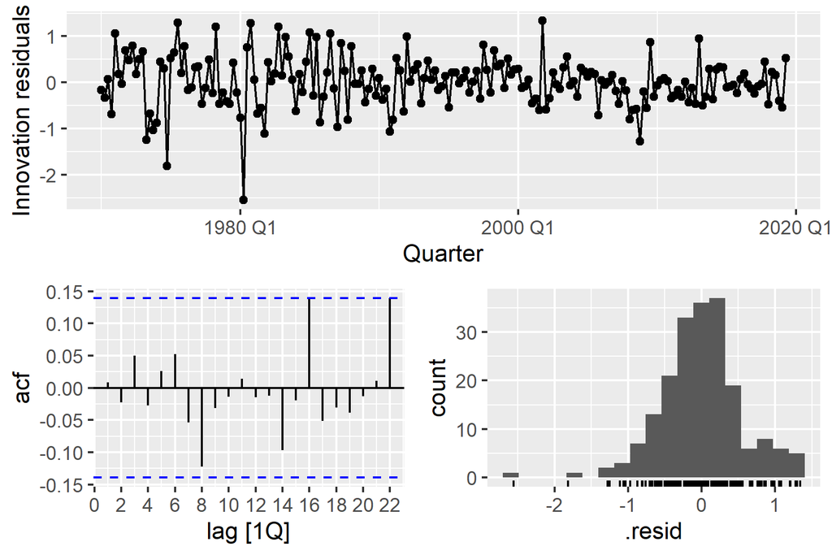

## 4. 잔차 복원

```r
augment(fit) |>
  features(.innov, ljung_box, dof = 3, lag = 8)
```

```
## # A tibble: 1 × 3
##   .model                      lb_stat lb_pvalue
##   <chr>                         <dbl>     <dbl>
## 1 ARIMA(Consumption ~ Income)    5.21     0.391
```

## 예측: 회귀 + ARIMA 오차모형의 예측

## 1. 예측의 기본 원리

ARIMA 오차를 가진 회귀모형에서 예측하려면

1. 회귀식의 예측
2. ARIMA 오차항의 예측

을 모두 수행하여 **결합**해야 한다.

### 예측변수의 미래값 필요

- 미래값이 **이미 알려진 경우** (예: 시간, 요일 등) → 단순
- 미래값이 **알려지지 않은 경우**  
  → 예측변수 자체를 모델링하거나  
  → **시나리오 기반 미래값**을 사용

## 2. 예제: 미국 개인소비와 소득

### 가정

향후 8개 분기 동안  
- 가처분소득 변화율 = 과거 40년 평균 변화율

### 특징

- 회귀모형에 공변량(소득)이 포함되므로  
  **ARIMA-only 모델보다 예측구간이 좁아짐**
- 하지만 중요한 점: > 회귀모형의 예측구간은  
  > **예측변수 자체의 미래 예측 불확실성을 반영하지 않음**

따라서 예측구간은  
**조건부(conditional) 예측구간**으로 해석해야 한다.

## 2. 예제: 미국 개인소비와 소득

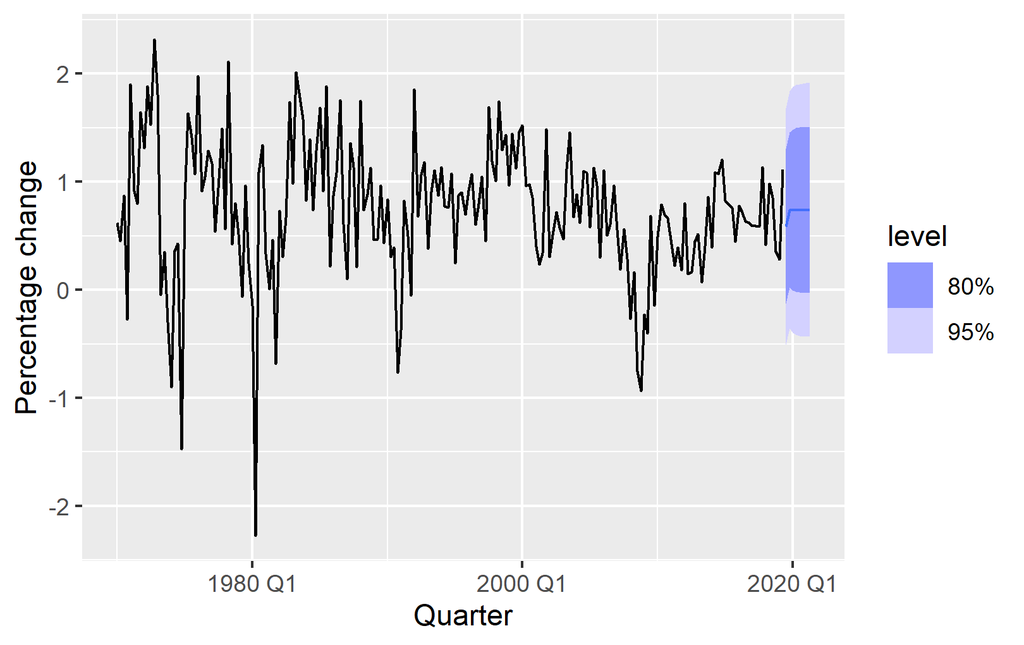

## 3. 예제: 전력수요 예측

### 데이터

- daily demand
- daily max temperature
- public holiday indicator  
  (데이터: `vic_elec_daily`)

### 패턴

- U자형 관계 (추운 날·더운 날 수요 증가)
- 비선형 + 동적 특성 필요  
  → quadratic regression + ARMA errors 사용

## 3. 예제: 전력수요 예측

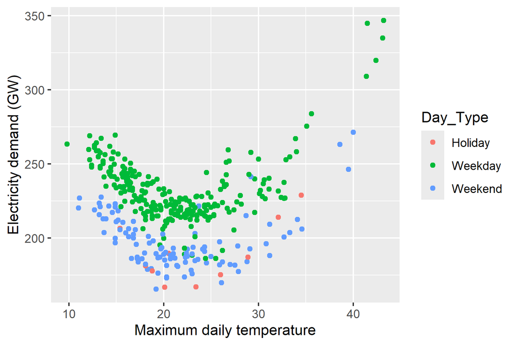

## 3. 예제: 전력수요 예측

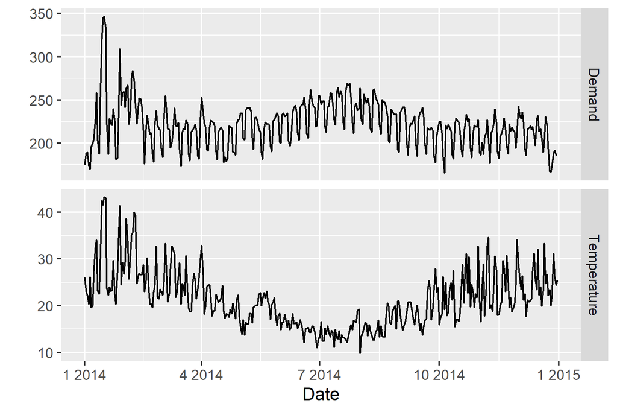

## 3. 예제: 전력수요 예측

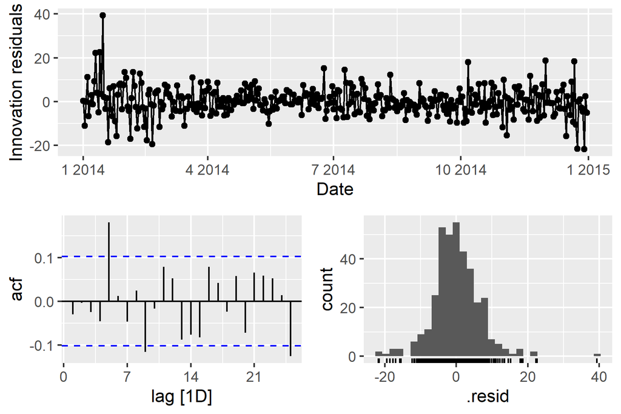

## 3. 예제: 전력수요 예측

### 적합 모형

- Quadratic regression + workday indicator
- Error: **ARIMA(2,1,2)(2,0,0)[7]**
- 총 6개 AR/MA 계수

## 3. 예제: 전력수요 예측

```r
augment(fit) |>
  features(.innov, ljung_box, dof = 6, lag = 14)
```

```
## # A tibble: 1 × 3
##   .model                                                       lb_stat lb_pvalue
##   <chr>                                                          <dbl>     <dbl>
## 1 "ARIMA(Demand ~ Temperature + I(Temperature^2) + (Day_Type …    28.4  0.000404
```

### 잔차 진단

- 이분산성 존재
- 일부 자기상관 잔존
- 긴 꼬리(long tails)  
  → 예측구간 신뢰도는 낮아질 수 있으나  
  → **점예측은 여전히 유효**

## 4. 14일 ahead 예측

시작일: 2015-01-01 (목, 공휴일)

### 시나리오 기반 예측

- 향후 14일간의 최고기온을 **26°C**로 가정
- (기상청 예측을 사용할 수도 있으나 예제에서는 단순화)

## 4. 14일 ahead 예측

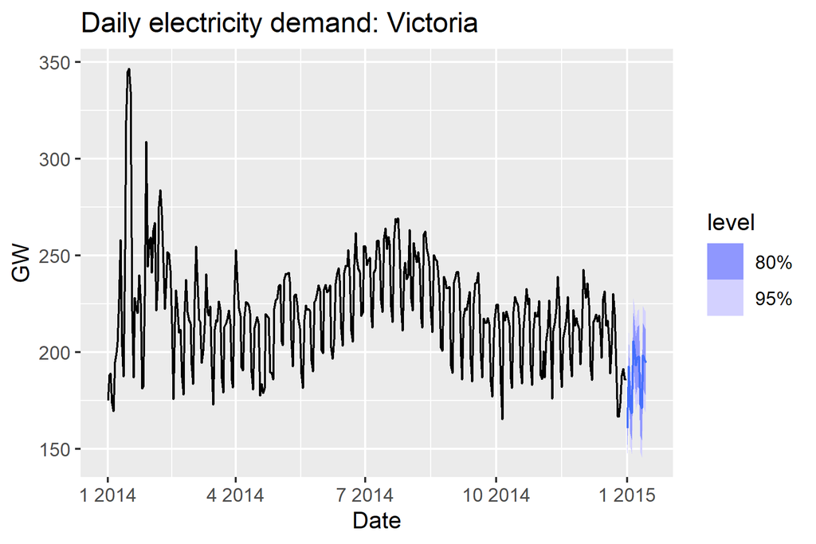

## 4. 14일 ahead 예측

### 예측 결과

- 2014년 말 전력수요 감소가 모형에 반영되어  
  → 2015년 첫 2주도 **낮은 전력수요 예측**
- 휴가철 seasonal effect가 영향을 미침

### 요약

- 회귀+ARIMA 모형은 예측변수의 미래값이 필수
- 공변량을 포함하면 예측불확실성을 줄일 수 있음
- 전력수요 예측은 비선형성과 계절성, ARMA 오류 모두 중요
- 시나리오 기반 예측은 실무에서 매우 유용한 접근

## 확률적(Stochastic) vs 결정적(Deterministic) 추세

## 1. 선형 추세의 두 가지 모델링 방식

### ■ 결정적 추세 (Deterministic Trend)

\[ y_t = \beta_0 + \beta_1 t + \eta_t \] - \(\eta_t\): **ARMA 과정**

### ■ 확률적 추세 (Stochastic Trend)

\[ y_t = \beta_0 + \beta_1 t + \eta_t \] - \(\eta_t\): **ARIMA 과정, \(d = 1\)**

## 1. 선형 추세의 두 가지 모델링 방식

#### 차분하면

\[ y'_t = \beta_1 + \eta'_t \] → 즉, \[ y_t = y_{t-1} + \beta_1 + \eta'_t \]

- 랜덤워크 + drift와 유사
- 다만 오차가 ARMA임

## 2. 예제: 1970–2016년 호주 국내 항공사 여객 수송량

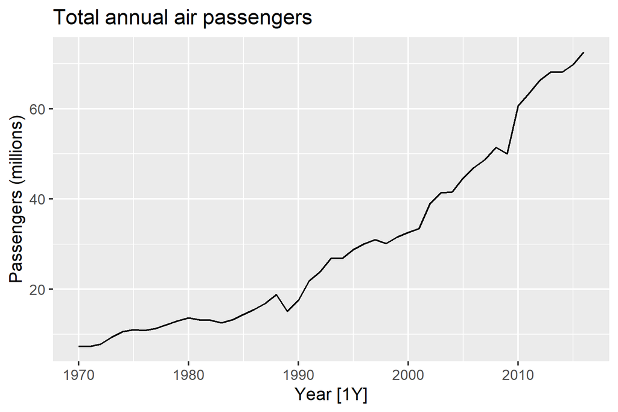

## 2. 예제: 호주 항공 여객 수송량

### (1) 결정적 추세 모형

```r
fit_deterministic <- aus_airpassengers |>
  model(deterministic = ARIMA(Passengers ~ 1 + trend() +
                                pdq(d = 0)))
report(fit_deterministic)
```

```
## Series: Passengers
## Model: LM w/ ARIMA(1,0,0) errors
##
## Coefficients:
##          ar1  trend()  intercept
##       0.9564   1.4151     0.9014
## s.e.  0.0362   0.1972     7.0751
##
## sigma^2 estimated as 4.343:  log likelihood=-100.88
## AIC=209.77   AICc=210.72   BIC=217.17
```

## 2. 예제: 호주 항공 여객 수송량

### (1) 결정적 추세 모형

\[ y_t = 0.901 + 1.415 t + \eta_t \] \[ \eta_t = 0.956\eta_{t-1} + \varepsilon_t, \quad \varepsilon_t \sim NID(0,4.343) \]

- **연간 증가량 ≈ 1.42백만 명**

## 2. 예제: 호주 항공 여객 수송량

### (2) 확률적 추세 모형

```r
fit_stochastic <- aus_airpassengers |>
  model(stochastic = ARIMA(Passengers ~ pdq(d = 1)))
report(fit_stochastic)
```

```
## Series: Passengers
## Model: ARIMA(0,1,0) w/ drift
##
## Coefficients:
##       constant
##         1.4191
## s.e.    0.3014
##
## sigma^2 estimated as 4.271:  log likelihood=-98.16
## AIC=200.31   AICc=200.59   BIC=203.97
```

## 2. 예제: 호주 항공 여객 수송량

### (2) 확률적 추세 모형

\[ y_t - y_{t-1} = 1.419 + \varepsilon_t \]

또는,

\[ y_t = y_0 + 1.419 t + \eta_t \] \[ \eta_t = \eta_{t-1} + \varepsilon_t, \quad \varepsilon_t \sim NID(0,4.271) \]

- **연간 증가량 ≈ 1.42백만 명**

## 3. 예측구간의 차이

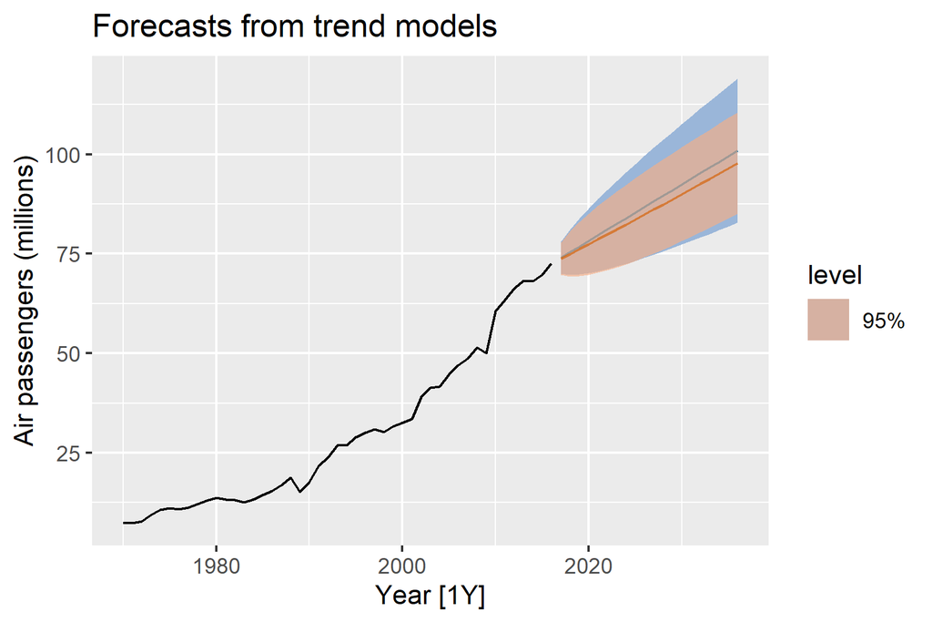

## 3. 예측구간의 차이

- 증가량은 비슷하지만  
  **확률적 추세의 예측구간이 훨씬 넓음**
- 이유: 확률적 추세는 **비정상 오차(누적되는 불확실성)**

## 4. 해석의 차이

### 결정적 추세

- 기울기(증가율)가 **시간에 따라 변하지 않는다고 가정**

### 확률적 추세

- 추세가 **시간에 따라 변할 수 있음**
- 추정 증가율 = 과거 평균 증가율
- 미래에도 동일하다는 보장은 없음

## 5. 결론: 어느 모델이 더 안전한가?

- **장기 예측 → 확률적 추세(Stochastic Trend)가 더 안전**
- 예측구간이 미래 불확실성을 더 잘 반영하기 때문

## 동적 조화 회귀

## 1. 왜 조화 호귀를 사용하는가?

### 긴 계절주기 예

- Daily: 365
- Weekly: 52
- Half-hourly: 하루 48을 포함한 다중 계절성

ARIMA/ETS의 계절성은 **짧은 주기(12, 4 등)** 에 최적화되어 있음.  
계절 주기 \(m\) 일 때 초기 계절 상태 파라미터가 **\(m-1\)** 개 필요 →  
**m이 크면 추정 불가능**

`ARIMA()`는 \(m \le 350\) 허용하지만 실제론 **m ≥ 200부터 메모리 문제** 발생.

## 2. 해결책: 동적조화회귀(Dynamic Harmonic Regression)

계절 패턴:

- Fourier 항으로 모델링

단기(time-series) 동학:

- ARMA 오차로 설명

### **Fourier항이란?**

- 계절성을 **사인(sin)과 코사인(cos) 함수**로 표현하여 어떤 길이의 계절성이라도 유연하게 모델링할 수 있다.

## Fourier 항의 기본 아이디어

Fourier 정리(Fourier theorem):

> “어떤 주기적 함수도 여러 개의 사인·코사인 함수의 조합으로 표현할 수 있다.”

\[ S_t = \sum_{k=1}^{K} \left[ a_k \sin\left( \frac{2\pi k t}{m} \right) + b_k \cos\left( \frac{2\pi k t}{m} \right) \right] \]

여기서  
- \(m\) = 계절 주기(예: 연간=365, 월간=12)  
- \(k\) = harmonic index (1, 2, …, K)  
- \(K\) = sin-cos pair의 개수  
- \(a_k\), \(b_k\) = 계수(coefficient)

## Fourier 항이 의미하는 것

### (1) 주파수와 k의 의미

- \(k = 1\) → 가장 부드러운 1차 계절 패턴
- \(k = 2\) → 더 빠르게 진동하는 패턴
- \(k = 3\) 이상 → 점점 더 복잡하고 ‘울퉁불퉁한(wiggly)’ 패턴

즉, K가 커질수록 보다 다양한 형태의 계절성을 반영할 수 있다.

## 서로 다른 K에 따른 Fourier항의 계절 패턴

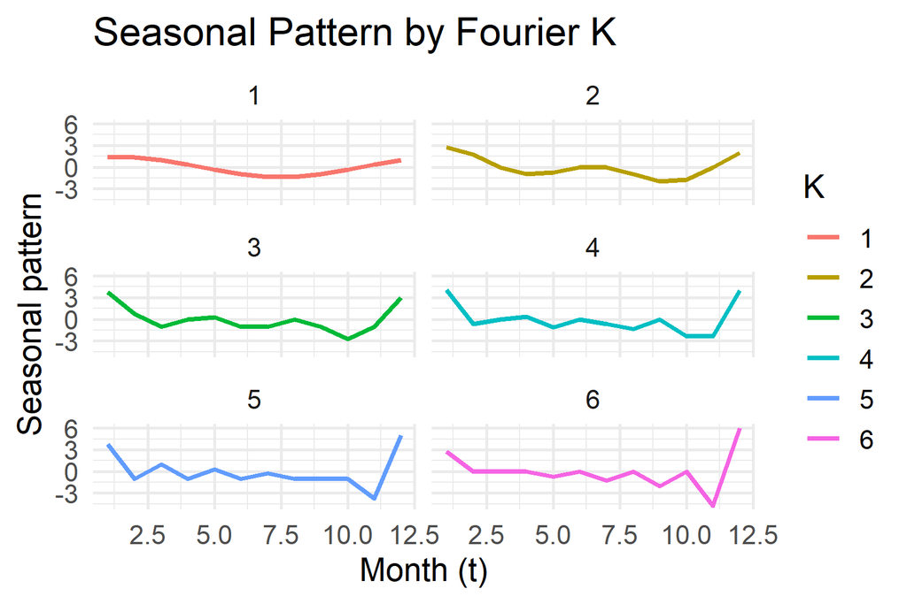

## 3. Fourier항의 장점

1. **어떤 길이의 seasonality도 가능**
2. 여러 seasonality → 각 주기의 Fourier term 포함 가능
3. 부드러움 조정 가능
   - \(K\): Fourier sin/cos pair 개수
   - 적은 K → 부드러운 계절패턴
4. 단기 동학을 ARMA로 간단히 모델링

## 4. Fourier항의 단점

- 계절성은 **시간에 따라 변하지 않는다고 가정**
- 하지만 실무에서는 seasonality가 대부분 매우 안정적 → 큰 문제 아님

## 5. 예제: 호주 외식지출 (2004–2018)

- 월별 카페·레스토랑·테이크아웃 지출
- 목표: **24개월 ahead forecast**
- Fourier 항 \(K = 1 \sim 6\) 사용
  - \(K=6\) = seasonal dummy 포함과 동일

### K 증가 효과

- 더 복잡한(wiggly) 계절 패턴 반영
- 오차 ARIMA는 더 단순해짐
- **AICc 최소는 K=6**
  - K=4→5에서 큰 차이 발생

→ **K=6 모델로 예측 수행**

## 5. 예제: 호주 외식지출 (2004–2018)

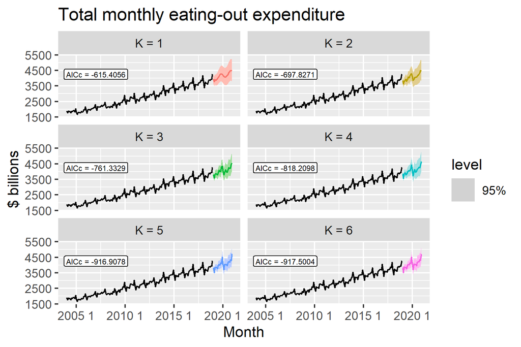

## 시차 예측변수

## 1. 왜 시차(lagged) 효과를 고려해야 하는가?

- 어떤 예측변수의 효과는 **즉각적이지 않을 수 있음**
- 예)
  - 광고 캠페인 → 캠페인 종료 후에도 지속적인 판매 효과
  - 안전정책 변화 → 처음에는 사고 감소, 시간이 지나면 효과 약화

👉 따라서 회귀모형에 **과거의 예측변수 값(lags)** 을 포함해야 정확한 모형을 만들 수 있음.

## 2. 시차 변수를 포함한 회귀 + ARIMA 오차모형

예측변수 \(x_t\)에 대해 최대 \(k\) 시차까지 포함하면:

\[ y_t = \beta_0 + \gamma_0 x_t + \gamma_1 x_{t-1} + \cdots + \gamma_k x_{t-k} + \eta_t \]

- \(\eta_t\): ARIMA 오차과정
- \(k\): 시차 길이 (AICc로 선택)
- ARIMA 오차의 \(p, q\)와 함께 동시에 선택 가능

## 3. 예제: TV 광고와 보험 견적

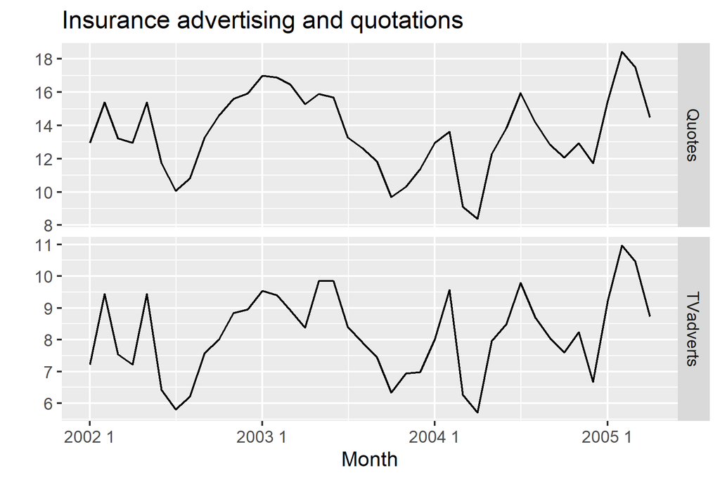

## 3. 예제: TV 광고와 보험 견적

### (1) 데이터

- 미국 보험회사
- 기간: 2002 Jan ~ 2005 Apr
- 변수:
  - 보험 견적 수(종속변수)
  - TV 광고비(예측변수)

### (2) 모형 비교 설정

- 광고비의 시차 0~3까지 포함 가능
- 모든 모형은 **동일한 훈련 구간**을 사용(앞 3개월 제외)

## 3. 예제: TV 광고와 보험 견적

- 모형을 fitting

```r
fit <- insurance |>
  # Restrict data so models use same fitting period
  mutate(Quotes = c(NA, NA, NA, Quotes[4:40])) |>
  # Estimate models
  model(
    lag0 = ARIMA(Quotes ~ pdq(d = 0) + TVadverts),
    lag1 = ARIMA(Quotes ~ pdq(d = 0) +
                 TVadverts + lag(TVadverts)),
    lag2 = ARIMA(Quotes ~ pdq(d = 0) +
                 TVadverts + lag(TVadverts) +
                 lag(TVadverts, 2)),
    lag3 = ARIMA(Quotes ~ pdq(d = 0) +
                 TVadverts + lag(TVadverts) +
                 lag(TVadverts, 2) + lag(TVadverts, 3))
  )
```

## 3. 예제: TV 광고와 보험 견적

### (3) 최적 시차 선택

```r
glance(fit)
```

```
## # A tibble: 4 × 8
##   .model sigma2 log_lik   AIC  AICc   BIC ar_roots  ma_roots
##   <chr>   <dbl>   <dbl> <dbl> <dbl> <dbl> <list>    <list>
## 1 lag0    0.265   -28.3  66.6  68.3  75.0 <cpl [2]> <cpl [0]>
## 2 lag1    0.209   -24.0  58.1  59.9  66.5 <cpl [1]> <cpl [1]>
## 3 lag2    0.215   -24.0  60.0  62.6  70.2 <cpl [1]> <cpl [1]>
## 4 lag3    0.206   -22.2  60.3  65.0  73.8 <cpl [1]> <cpl [1]>
```

- 기준: **AICc**
- 결과: **lag1 모델이 최적**
  - 포함된 예측변수: \(x_t\), \(x_{t-1}\)

## 4. 선택된 최종모형

```r
fit_best <- insurance |>
  model(ARIMA(Quotes ~ pdq(d = 0) +
              TVadverts + lag(TVadverts)))
report(fit_best)
```

```
## Series: Quotes
## Model: LM w/ ARIMA(1,0,2) errors
##
## Coefficients:
##          ar1     ma1     ma2  TVadverts  lag(TVadverts)  intercept
##       0.5123  0.9169  0.4591     1.2527          0.1464     2.1554
## s.e.  0.1849  0.2051  0.1895     0.0588          0.0531     0.8595
##
## sigma^2 estimated as 0.2166:  log likelihood=-23.94
## AIC=61.88   AICc=65.38   BIC=73.7
```

## 4. 선택된 최종모형

\[ y_t = 2.155 + 1.253 x_t + 0.146 x_{t-1} + \eta_t \]

오차항:

\[ \eta_t = 0.512 \eta_{t-1} + \varepsilon_t + 0.917 \varepsilon_{t-1} + 0.459 \varepsilon_{t-2} \]

- ARIMA(1,0,2) 오차
- \(\varepsilon_t\): white noise

## 5. 예측(Forecasting)

미래 예측을 위해서는 **광고비의 미래값**이 필요.

예: - 광고비가 앞으로 **모든 달에서 8 단위**라고 가정 → 예측 생성

👉 시차효과가 있는 회귀모형에서는  
**예측변수 미래값(또는 시나리오 기반 값)** 이 반드시 필요함.

## 5. 예측(Forecasting)

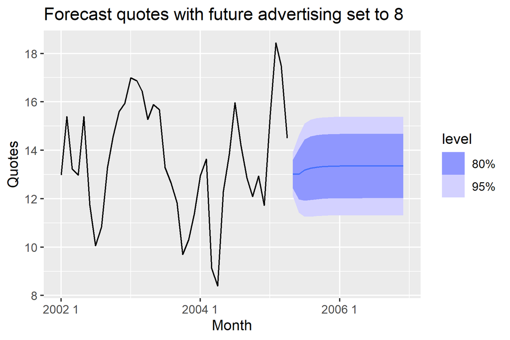

## 요약

- 시차효과는 마케팅·정책·경제 변수에서 매우 흔함
- 시차 길이(k)는 AICc로 선택
- 회귀 + ARIMA 오차 = 강력한 예측 모형
- 예측 시 predictor의 미래값 가정이 필요